# 3-2: Stochastic population growth model

## Overview

*In this practical we will run our first stochastic simulations, starting with the stochastic version of the population growth model. From now on, we will expect a brief report in some format on every practical, so we will not give explicit guidance in every case.*

## Background

In the lecture, we discussed the fact that the **deterministic models** we have been using so far don’t handle dynamics at the individual level well. To capture individual-level behaviour we need to include an element of chance in the model. This new type of model, which includes a probabilistic element, is called a **stochastic model**.

## Tasks

To write a model to handle stochastic population dynamics we obviously have to update the timestep function to handle the new dynamics. However, we also have to understand whether anything else has changed in how the simulation works. In fact, something has. There is now the chance that the population will die out before the end of the experiment, so we need to look for this happening – not least to speed up the simulation.

### demo/d0302_stochastic_birth_death.R

We’ll start by writing the structural code in a new demo file, demo/d0302_stochastic_birth_death.r, remembering to add an entry in demo/00Index. You can use the d0301_run_birth_death demo – simulating birth-death population dynamics from Practical 1-5 – in {githubusername} as a template.

From Practicals 2-3 and 2-4 we have a `while()` loop which runs the simulation:

```r
while (latest.population$time < end.time) {
  latest.population <- timestep_deterministic_SIR(# -- some arguments -- )
  population.df <- rbind(population.df, latest.population)
}
```

The loop ends when the time runs out. Now, instead, there are two reasons why we might stop the simulation – the time may have run out, or the timestep code may identify that the dynamics are now complete. To achieve this, the timestep code will have to return both the updated population and whether the simulation is over. We suggest doing something like this:

```r
while (keep.going) {
  data <- timestep_stochastic_birth_death(# -- some arguments -- )
  latest.population <- data$updated.pop
  population.df <- rbind(population.df, latest.population)
  # The experiment may end stochastically or the time may run out
  keep.going <- (!data$end.experiment) && (latest.population$time < end.time)
}
```

Notice that at the start of the loop `keep.going` has not yet been defined, which will cause an error, so you will need to start it off with an appropriate value.

Remember to call `library(RPiR)` at the top of the script to load `plot_populations()`, and `library(githubusername)` to load `timestep_stochastic_birth_death()`, which means you no longer need to source any helper files.

### R/timestep_stochastic_birth_death.R

Now you will need to write the `timestep_stochastic_birth_death()` function to provide the right information to the main loop. We already have a deterministic step function for single species population dynamics (from Practical 1-5). We’ve written this function into {githubusername} as `step_deterministic_birth_death()`. Starting with this code, you need to make three changes.

First, we need to handle the effect of changing timesteps and update the code with something like this:

```r
timestep_stochastic_birth_death <- function(latest, birth.rate, death.rate, timestep) {
effective.birth.rate <- birth.rate * timestep
# -- some code to determine the numbers of new births and deaths --
next.population <- data.frame(time = latest$time + timestep, # -- some code -- )
# -- some code to calculate whether the experiment is finished --
}
```

Then we need to work out whether the simulation has ended and return both pieces of information – the updated population and simulation state, by returning a list like this at the end of the function (since a function can only return one item, we will have to return a list with two elements):

```r
timestep_stochastic_birth_death <- function(latest, birth.rate, death.rate, timestep) {
  effective.birth.rate <- birth.rate * timestep
  # -- some code to determine the numbers of new births and deaths --
  next.population <- data.frame(time = latest$time + timestep, # -- some arguments -- )
  # -- some code to calculate whether the experiment is finished --
  list(updated.pop = next.population,
       end.experiment = is.finished)
}
```

But we need to determine whether the experiment is finished first – before the end of the function! In this case, the experiment will only end if the population completely dies out, so:

```r
is.finished <- the.number.of.individuals.left == 0
```

Finally, we need to make the simulation stochastic using `rbinom()`. Remember, if you want to draw once from the binomial distribution with `count` trials, and a probability of success of `prob`, then the number of successes is:

```r
new.events <- rbinom(1, count, prob)
```

So, the key is to use the `rbinom()` function to determine the numbers of new births and deaths in each time step. The number of births is drawn from a binomial distribution with size `count` and probability `birth.rate * timestep`, and the number of deaths is drawn from the same distribution with probability `death.rate * timestep`.

Once you’re happy with your function, run `devtools::document()` to generate man/ files and edit the NAMESPACE. Then run `devtools::install()` to permanently install it.

## Running the code

When you are happy that the code is working and makes sense, run the code several times without changing any parameters of initial conditions and look at the output. The stochasticity means that we see variable outputs. If you don’t it may be because your starting population is too high. Try something much smaller, say 7 instead of 7 billion!

Remember that you can run your code as a demo,

```r
demo("d0302_stochastic_birth_death", package = "githubusername")
```

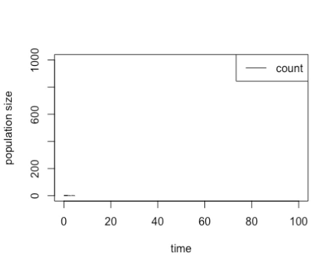

In this example we used these parameters:

```r
this.birth.rate <- 0.2
this.death.rate <- 0.1
initial.count <- 1
```

You could also increase birth and death rates or the time you’re simulating over to increase visible variability.

If you haven’t already, try increasing the value of timestep. What happens? You are actually getting impossible numbers (`NA`s) because the probability of giving birth has got above 1. You can fix this by using the `stop()` command in `timestep_stochastic_birth_death()` to stop running code when the numbers you put in are impossible:

```r
if ((effective.birth.rate >= 1) || (effective.death.rate >= 1))
  stop("Effective rate too high, timestep must be too big")
```

Rerun the code and check it stops when appropriate.